# Using Silver and Bighead Carp cell lines for the identification of a unique metabolite fingerprint from thiram-specific chemical exposure

Joel G. Putnam, Justine E. Nelson, Eric M. Leis, Richard A. Erickson, Terrance D. Hubert, and Jon J. Amberg

August 5, 2016

## Figures 6

This section of R code collects the data to be graphed.

```r
SVC<-read.csv("SVC thiram data labels.csv")
BHC<-read.csv("BHC thiram data.csv")
formula.SVC<-read.csv("list.formula.csv")
```

This section of code opens all the packages needed to create the graphs.

```r
library(vegan)
library(caTools)
library(bitops)
library(ggplot2)
library(reshape2)
library(data.table)
library(gtools)
library(scales)
library(gtable)
library(grid)
library(gridExtra)
library(extrafont)
```

This section of code adds the Times New Roman font used in the manuscript to the graphs.

```r
loadfonts(device="pdf")
loadfonts(device="win")
```

A function to calculate the error:

```r
se <- function(x) sqrt(var(x)/length(x))
```

The graphs to be created need 9 colors to be defined for each treatment level:

```r
cbPalette <- c("#999999", "#000000", "#E69F00", "#56B4E9", "#009E73", "#F0E442", "#0072B2", "#D55E00", "#CC79A7")
```

The graph needs text to be defined with font, size, and color

```r
leg.1<-theme(plot.title = element_text(lineheight=.8, face="bold",family="times")) +
  theme(legend.title = element_text(colour="black", size=10, face="bold",family="times")) +
  theme(axis.text=element_text(size=14,face="bold",color="black",family="times"),
        axis.title=element_text(size=10,face="bold",family="times")) +
  theme(plot.title = element_text(family="times", face="bold", colour="black", size=14))
my_grob.A<-grobTree(textGrob("A",x=0.01, y=0.9,hjust=0,
                             gp=gpar(col="black",fontsize=15,fontface="bold",  fontfamily="times")))
my_grob.B<-grobTree(textGrob("B",x=0.01, y=0.9,hjust=0,
                             gp=gpar(col="black",fontsize=15,fontface="bold",  fontfamily="times")))
```

The selection of data related to metabolomic markers which have both presence in untreatead cells and dose response in treated cells

```r
p.BHC.1<-cbind.data.frame(BHC$level,BHC$X296.076a8.17)
p.BHC.2<-cbind.data.frame(BHC$level,BHC$X370.094a8.53)
p.BHC.3<-cbind.data.frame(BHC$level,BHC$X388.104a8.17)
p.BHC.4<-cbind.data.frame(BHC$level,BHC$X462.122a8.87)
```

Calculation of the mean and error in abundances of selected metabolomic markers

```r
dd.11<-tapply(p.BHC.1[,2],BHC$level,mean)
dd.11.se<-tapply(p.BHC.1[,2],BHC$level,se)
dd.22<-tapply(p.BHC.2[,2],BHC$level,mean)
dd.22.se<-tapply(p.BHC.2[,2],BHC$level,se)
dd.33<-tapply(p.BHC.3[,2],BHC$level,mean)
dd.33.se<-tapply(p.BHC.3[,2],BHC$level,se)
dd.44<-tapply(p.BHC.4[,2],BHC$level,mean)
dd.44.se<-tapply(p.BHC.4[,2],BHC$level,se)
```

Binding and melting data into format usable by ggplot2:

```r
d.BHC<-cbind.data.frame(names(dd.11),as.numeric(dd.11),as.numeric(dd.22),as.numeric(dd.33),as.numeric(dd.44),
                        as.numeric(dd.11.se),as.numeric(dd.22.se),as.numeric(dd.33.se),as.numeric(dd.44.se))
names(d.BHC)<-c("level","X296.076","X370.094","X388.104","X462.122",
                "se.296","se.370","se.388","se.462")
t.BHC.melt<-melt(d.BHC,id.vars=c("level"),measure.vars=c("X296.076","X370.094","X388.104","X462.122"),variable_name=c("X296.076","X370.094","X388.104","X462.122"))
s.BHC.melt<-melt(d.BHC,id.vars=c("level"),measure.vars=c("se.296","se.370","se.388","se.462"),variable_name=c("se.296","se.370","se.388","se.462"))
BHC.melt<-cbind.data.frame(t.BHC.melt$level,t.BHC.melt$variable,t.BHC.melt$value,s.BHC.melt$value)
names(BHC.melt)<-c("level","Mass","mean","se")
```

Preparing graph of BHC data:

```r
gg4.BHC<-ggplot(BHC.melt,aes(x=factor(level),y=mean,color=Mass,group=Mass))+ggtitle("BHC fry cells response to thiram") +
  theme_bw() + annotation_custom(my_grob.A) +
  geom_line(linetype="dotted",  size=2) + xlab("") + ylab("") +
  geom_errorbar(aes(ymax = BHC.melt$mean + BHC.melt$se, ymin=BHC.melt$mean - BHC.melt$se), size=1,width=0.25) +
  leg.1+ scale_y_continuous(labels = scientific) +
  theme(plot.title = element_text(size=20,lineheight=1.5, face="bold",family="times")) +
  theme(legend.title = element_text(colour="black", size=10, face="bold",family="times")) +
  theme(legend.key.size = unit(1, "cm")) +
  scale_x_discrete(limits=c("Untreated","DMSO","Lv1 1.127 ppm","Lv2 1.873 ppm","Lv3 3.123 ppm","Lv4 5.208 ppm","Lv5 8.665 ppm","Lv6 14.43 ppm","Lv7 24.09 ppm")) +
  theme(legend.text = element_text(size=10,face="bold",color="black",family="times")) +
  theme(axis.text=element_text(size=6,face="bold",color="black",family="times"),
        axis.title=element_text(size=6,face="bold",family="times"))
```

This is the same calculations used for the BHC data:

```r
p.SVC.1<-cbind.data.frame(SVC$level,SVC$X296.0782a6.26)
p.SVC.2<-cbind.data.frame(SVC$level,SVC$X370.096a6.94)
p.SVC.3<-cbind.data.frame(SVC$level,SVC$X388.1062a6.26)
p.SVC.4<-cbind.data.frame(SVC$level,SVC$X462.1258a6.93)

dd.11<-tapply(p.SVC.1[,2],SVC$level,mean)
dd.11.se<-tapply(p.SVC.1[,2],SVC$level,se)
dd.22<-tapply(p.SVC.2[,2],SVC$level,mean)
dd.22.se<-tapply(p.SVC.2[,2],SVC$level,se)
dd.33<-tapply(p.SVC.3[,2],SVC$level,mean)
dd.33.se<-tapply(p.SVC.3[,2],SVC$level,se)
dd.44<-tapply(p.SVC.4[,2],SVC$level,mean)
dd.44.se<-tapply(p.SVC.4[,2],SVC$level,se)

d.SVC<-cbind.data.frame(names(dd.11),as.numeric(dd.11),as.numeric(dd.22),as.numeric(dd.33),as.numeric(dd.44),
                        as.numeric(dd.11.se),as.numeric(dd.22.se),as.numeric(dd.33.se),as.numeric(dd.44.se))
names(d.SVC)<-c("level","X296.076","X370.094","X388.104","X462.122",
                "se.296","se.370","se.388","se.462")
t.SVC.melt<-melt(d.SVC,id.vars=c("level"),measure.vars=c("X296.076","X370.094","X388.104","X462.122"),variable_name=c("X296.076","X370.094","X388.104","X462.122"))
s.SVC.melt<-melt(d.SVC,id.vars=c("level"),measure.vars=c("se.296","se.370","se.388","se.462"),variable_name=c("se.296","se.370","se.388","se.462"))
SVC.melt<-cbind.data.frame(t.SVC.melt$level,t.SVC.melt$variable,t.SVC.melt$value,s.SVC.melt$value)
names(SVC.melt)<-c("level","Mass","mean","se")

gg4.SVC<-ggplot(SVC.melt,aes(x=factor(level),y=mean,color=Mass,group=Mass))+ggtitle("SVC fry cells response to thiram") +
  theme_bw() + annotation_custom(my_grob.A) +
  geom_line(linetype="dotted",  size=2) + xlab("") + ylab("") +
  geom_errorbar(aes(ymax = SVC.melt$mean + SVC.melt$se, ymin=SVC.melt$mean - SVC.melt$se), size=1,width=0.25) +
  leg.1+ scale_y_continuous(labels = scientific) +
  theme(plot.title = element_text(size=20,lineheight=1.5, face="bold",family="times")) +
  theme(legend.title = element_text(colour="black", size=10, face="bold",family="times")) +
  theme(legend.key.size = unit(1, "cm")) +
  scale_x_discrete(limits=c("Untreated","DMSO","Lv1 2.309 ppm","Lv2 3.848 ppm","Lv3 5.599 ppm","Lv4 8.128 ppm","Lv5 11.88 ppm","Lv6 17.23 ppm","Lv7 28.98 ppm")) +
  theme(legend.text = element_text(size=10,face="bold",color="black",family="times")) +
  theme(axis.text=element_text(size=6,face="bold",color="black",family="times"),
        axis.title=element_text(size=6,face="bold",family="times"))
```

This code creates the common legend used in the figure:

```r
g_legend<-function(a.gplot){
  tmp <- ggplot_gtable(ggplot_build(a.gplot))
  leg <- which(sapply(tmp$grobs, function(x) x$name) == "guide-box")
  legend <- tmp$grobs[[leg]]
  return(legend)}

mylegend<-g_legend(gg4.BHC)
```

This combines the two graphs together:

```r
p2.2<-grid.arrange(arrangeGrob(gg4.BHC + theme(legend.position="none"),
                               gg4.SVC + theme(legend.position="none"),
                               nrow=2),nrow=1,ncol=1)
```

This code combines the two graphs and legend into one figure by arranging the layout:

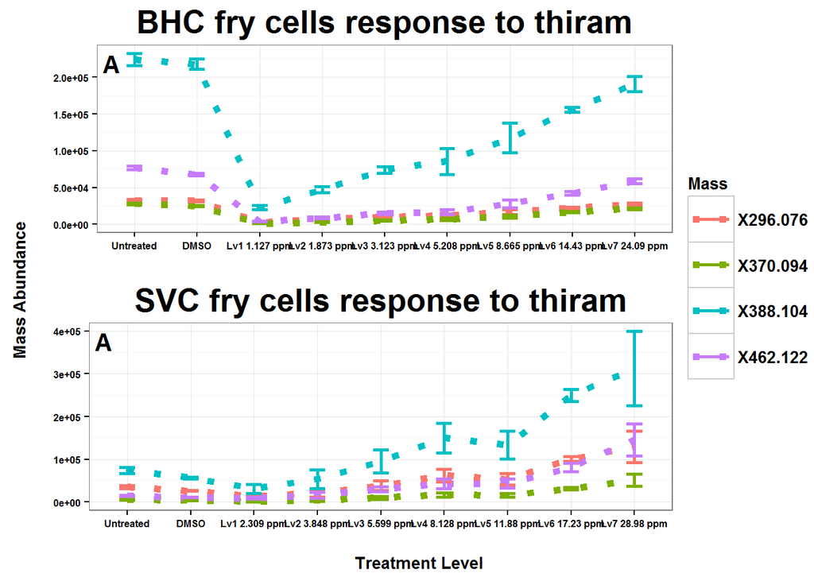

```r
p6 <- grid.arrange(arrangeGrob(p2.2),left = textGrob("Mass Abundance", rot = 90, vjust = 1,gp=gpar(fontsize=10,font=2,  fontfamily="times")),
                   bottom=textGrob("Treatment Level", vjust = 0,gp=gpar(fontsize=10,font=2,  fontfamily="times")),mylegend, nrow=2,ncol=2,heights=c(10, 0.01),widths=c(20,4))
```